# Privatização e concessões: Impactos na economia nacional

João Vitor

2023-05-26

[figure not shown]

Aluno; João Vitor da Silva Santos

Professor; Arthur Guerra Cisneiro

Curso; Economia

Disciplina; Macroeconomia II

Matrícula ;24254

# 1 Privatização e concessões: Impactos na economia nacional

## 1.1 Privatização x Concessão

- Na privatização, há uma alienação permanente de uma empresa ou serviço público à iniciativa privada. O Estado não exerce mais a gestão daquele bem, que se torna responsabilidade absoluta e definitiva do administrador privado.
- concessão, ocorre uma transferência temporária da gestão do Estado para o setor privado. A concessionária daquela companhia ou serviço pode explorá-lo, obter lucro e fazer os investimentos que julgar pertinentes. Porém, a empresa voltará ao controle do Estado ao fim do período estipulado em contrato.

## 1.2 Pontos posítivos da privatização

1. Enxugamento do aparelho de Estado;
2. Diminuição da burocracia;
3. Melhoria da qualidade dos serviços prestados;
4. Aumento da eficiência;
5. Redução da folha salarial e de gastos de forma geral;
6. Possibilidade de os governos organizarem seus recursos de forma mais racional, investindo em áreas prioritárias;
7. Lucros maiores;
8. Maior geração de riqueza.

## 1.3 Pontos negativos da privatização

1. Desvalorização do patrimônio público;
2. Perda da soberania do Estado em setores estratégicos;
3. Concentração de lucros em empresas do setor privado, com possibilidade de formação de monopólios;
4. Falta de planejamento de longo prazo;
5. Perda da capacidade de investimento;
6. Aumento do número de trabalhadores terceirizados e não formais;
7. Maior precarização do trabalho;
8. Tendência à diminuição da renda dos trabalhadores.

| Privatizações Governo Federal Governo Federal | Privatizações Governo Federal Privatizações |
| --- | --- |
| Governo Collor (1990-1992) | Usiminas, Celma, Cosinor |
| Governo Itamar (1992-1994) | Embraer, CSN |
| Governo FHC (1995-2002) | Vale, Telebras, Embratel, Banespa, Banco Meridional |
| Governo Lula (2003-2010) | Rodovias federais, Hidrelétrica Santo Antônio, Hidrelétrica Jirau |
| Governo Dilma (2011-2016) | Rodovias, Aeroportos |
| Governo Temer (2016-2018) | Eletroacre, Ceron |
| Governo Bolsonaro (2019-2022) | Eletrobras, Codesa, BR Distribuidora, Liquigás |

# 2 Governo Collor (1990 - 1992)

## 2.1 Usiminas

- Usiminas ( Usinas Siderurgicas de Minas Gerais S.A) é uma empresa do setor siderúrgico, líder na produção e comercialização de aços planos .

> “Graças à sua situação financeira favorável e à alta qualidade operacional, a Usiminas foi escolhida para ser a primeira empresa a ser privatizada, o que ocorreu em 1991, servindo como símbolo de um novo momento econômico e social brasileiro.”

> ” Para dar exemplos, a própria Usiminas, alguns poucos anos depois de sua privatização, foi eleita como a Melhor Empresa do Brasil por um ranking confiável, ampliamos nossa atuação com aquisições e entrada em segmentos complementares, como mineração e serviços.”

##### 2.1.0.0.1 SERGIO LEITE - Presidente da Usiminas

# 3 Governo Itamar (1992-1994)

## 3.1 Embraer

- A Empresa Brasileira de Aeronáutica (Embraer) foi privatizada por R$ 154,1 milhões, que corrigido pelo IPCA, é equivalente a R$ 1.025.425.349,32
- Após a privatização, a Embraer expandiu sua linha de produtos, desenvolvendo novos modelos de aeronaves comerciais, executivas e militares. A empresa também se destacou no mercado de jatos regionais, com a família de aeronaves E-Jets, que se tornou um grande sucesso global.

# 4 Governo FHC (1995-2002)

## 4.1 Vale

- Companhia Vale do Rio Doce, a Vale, foi privatizada no ano de 1997, pelo valor de R$ 3,3 bilhões, corrigido pelo IPCA,o valor foi de R$ 155.496.138.600,00. No mesmo ano a empresa se valorizou em 3.500% tendo seu valor de mercado R$ 452 bilhões.

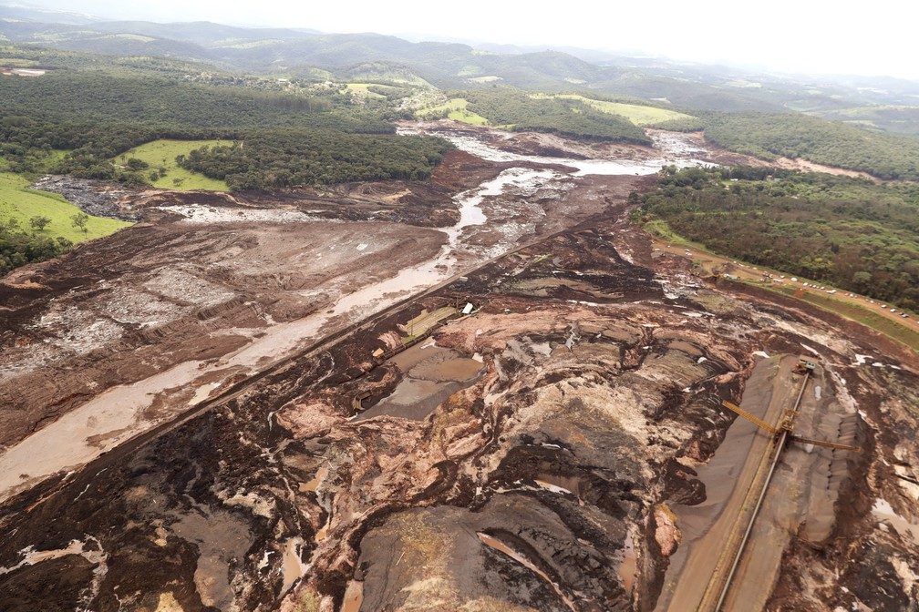

Brumadinho

## 4.2 Telebras

- A privatização da Telebras ocorreu em 29 de julho de 1998 em doze leilões consecutivos na Bolsa de Valores do Rio de Janeiro. A época a empresa foi desmembrada em oito operadoras de telefonia móvel, três de telefonia fixa e uma de longa distância, são elas:
- Telebras o Governo possuía 19% das ações ordinárias, sendo que o restante já estava pulverizado nas mãos de milhões de acionistas privados. Foram esses 19% leiloados e que captaram R$22,05 bilhões.
- A privatização da Telebras foi considerado pela revista Privatization do Reino Unido o maior valor obtido por uma empresa de telecomunicações no anos 90. Naquela época uma linha telefônica custava entre US$1 mil e US$3 mil e demorava de 24 até 60 meses para ser instalada pelo plano de expansão.

| Segmento | Concessao | Comprador |
| --- | --- | --- |
| Telefonia fixa | Tele Centro Sul – Brasil Telecom | Fundos de pensão, Banco Opportunity e Telecom Itália |
| Telefonia fixa | Tele Norte Leste – Telemar | Grupo AG Telecom |
| Telefonia fixa | Telesp | Telefônica |
| Telefonia móvel | Telesp Celular | Portugal Telecom |
| Telefonia móvel | Tele Sudeste Celular | Telefônica |
| Telefonia móvel | Telemig Celular | Consórcio Telepart Participações S/A, Telesystem International Wireless, banco Opportunity e fundos de pensão |
| Telefonia móvel | Tele Celular Sul | UGB Participações e Bitel (Telecom Itália) |
| Telefonia móvel | Tele Nordeste Celular | UGB Participações e Bitel (Telecom Itália) |
| Telefonia móvel | Tele Centro Oeste Celular | Splice do Brasil |
| Telefonia móvel | Tele Leste Celular | Iberdrola e Telefónica de España |
| Telefonia móvel | Tele Norte Celular | Telepart Participações, Telesystem International Wireless, banco Opportunity e fundos de pensão |
| Longa distância | Embratel | MCI Internacional |

# 5 Governo Lula (2003-2010)

## 5.1 Ferrovia Norte-Sul

> Em outubro de 2007, a operação do trecho da Ferrovia Norte-Sul entre Açailândia (MA) e Porto Nacional (TO) foi concedido pela VALEC à Vale, por um período de 30 anos. A companhia foi a única interessada no leilão, pagando o valor mínimo de R$ 1,478 bilhão de reais, sendo R$ 740 milhões em 21 de dezembro de 2007, quando da assinatura do contrato e os 50% restantes pagos em duas parcelas, corrigidas pelo IGP-DI e acrescidas de juros de 12% ao ano, vencendo em dezembro de 2008 e de 2009. O trecho concedido foi de 722 km, porém somente o trecho entre Açailândia (MA) e Araguaína (TO), com 361 km de extensão, estava concluído em outubro de 2007. Com o dinheiro pago pela concessão, foi realizada a construção do trecho entre Araguaína (TO) e Porto Nacional (TO), com 359 km de extensão.

# 6 Governo Dilma (2011-2016)

## 6.1 Aeroportos (como os de Guarulhos e Brasília)

> Em 7 de janeiro de 2011, a presidente Dilma Rousseff decidiu conceder o aeroporto para a iniciativa privada. Segundo o edital, o consórcio vencedor deveria administrar o aeroporto por um período de 20 anos e fazer as ampliações necessárias. A medida foi adotada para que Cumbica recebesse os investimentos para adequar-se ao aumento da demanda durante a Copa do Mundo FIFA de 2014. Em 21 de julho de 2011, Rousseff assinou decreto incluindo o terminal de Guarulhos no Programa Nacional de Desestatização e delegando à Agência Nacional de Aviação Civil responsabilidade por executar e acompanhar o processo. A assinatura do contrato de concessão ocorreu em 6 de fevereiro de 2012, para o consórcio Invepar/Airports Company South Africa (ACSA) que ficou com 51% da administração do aeroporto e a estatal Infraero com os outros 49%, durante o período de 20 anos, pelo valor 16,2 bilhões de reais.

> O complexo aeroportuário foi concedido à iniciativa privada em 6 de fevereiro de 2012 para o Consórcio Inframérica durante o período de 25 anos, pelo valor de 4,5 bilhões de reais.

# 7 Governo Temer (2016-2018)

> O governo federal vai lançar nesta terça-feira o segundo pacote de 54 parcerias público-privadas na área de infraestrutura, com um valor de investimento estimado em 45 bilhões de reais. Desta vez, serão incluídas concessões em linhas de transmissão de energia, portos, ferrovias e uma rodovia. Todos os projetos serão incluídos no Programa de Parceria em Investimentos para terem prioridade na análise em qualquer órgão do governo federal.

# 8 Governo Bolsonaro (2019-2022)

## 8.1 Eletrobras

- A privatização movimentou, na estreia, R$ 33,7 bilhões. Ao longo dos próximos anos, serão outros mais de R$ 30 bilhões.
1. R$ 32 bilhões serão destinados à Conta de Desenvolvimento Energético (CDE) ao longo dos próximos 25 anos, sendo que R$ 5 bilhões serão pagos ainda em 2022. O objetivo é atenuar os reajustes tarifários e subsidiar políticas setoriais;
2. R$ 25,3 bilhões vão para o caixa do Tesouro e se referem ao chamado bônus de outorga, que será pago pela Eletrobras privatizada à União pela renovação dos contratos das 22 usinas hidrelétricas da empresa;
3. R$ 9,7 bilhões são compromissos de investimento em bacias hidrográficas, que deverão ser realizados em um período de 10 anos.

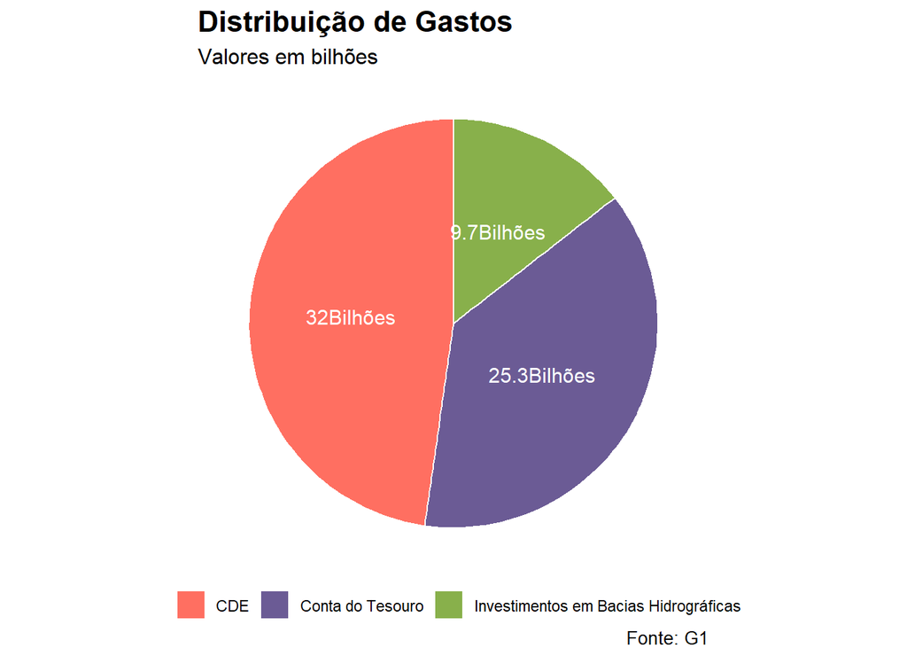

## 8.2 Companhia Docas do Espírito Santo (Codesa)

- O fundo de investimentos Shelf 119 Multiestratégia, da gestora Quadra Capital, a Companhia Docas do Espírito Santo (Codesa) e será o responsável pela gestão da administradora de portos pelos próximos 35 anos.
- O fundo vencedor ofertou uma outorga no valor de R$ 106 milhões pela concessão

## 8.3 BR Distribuidora

[figure not shown]

## 8.4 Liquigás

- A Petrobras em 2019, vendeu as ações da Liquígas, para a Copagaz e a Nacional Gas Butano, via leilão, recebendo um montante de aproximadamente R$ 4 bilhões na venda.
- Regulamentação: A transação de venda passou pela aprovação do Conselho Administrativo de Defesa Econômica (CADE) e de outros órgãos reguladores competentes para garantir a conformidade com as leis antitruste e proteção ao consumidor.

|  |  | Líquigás | copagaz | nacional gás butano |
| --- | --- | --- | --- | --- |
| 2 | REVENDEDORES | 48000 | 2261 | 3500 |
| 3 | PARTICIPAÇÃO | 21.4% | 8.8% | 20.10% |
| 4 | CONSUMIDORES | 26 milhões | 36.4 milhões | 7.5 milhões |

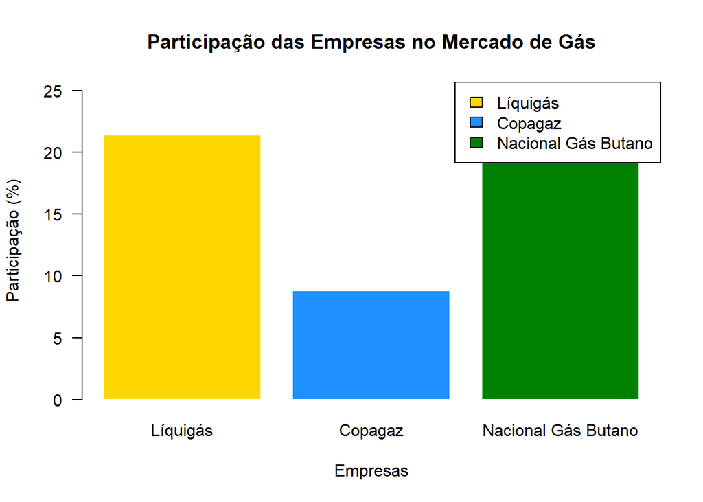

# 9 Comparação do setor privado e público

[output not shown]

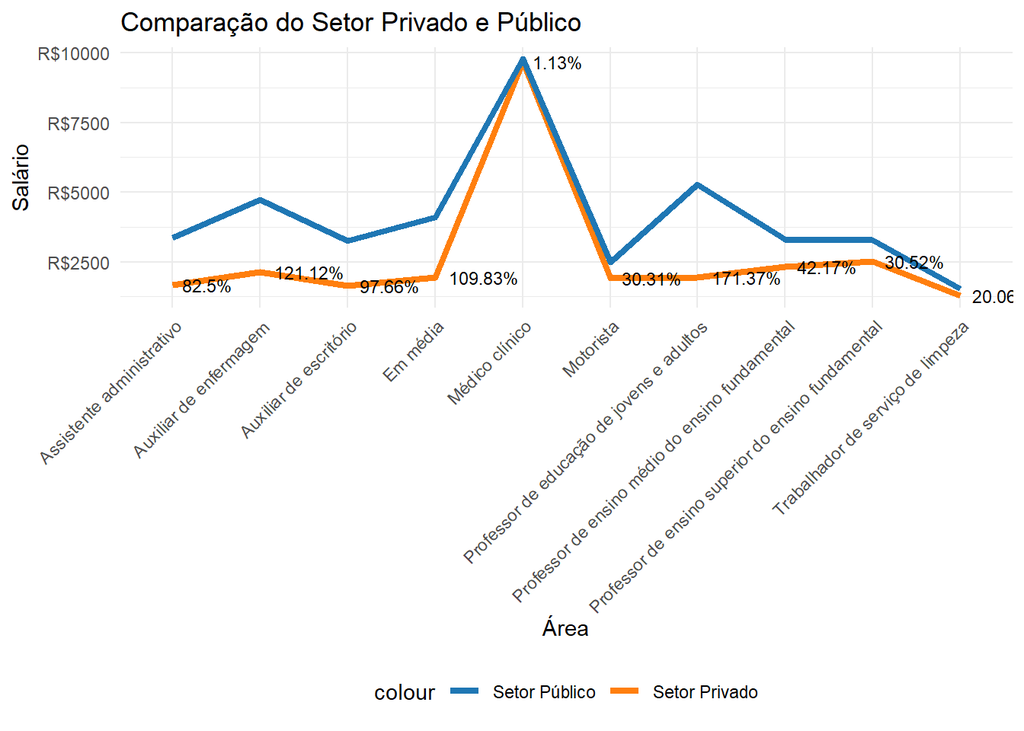

## 9.1 Comparação das rodovias

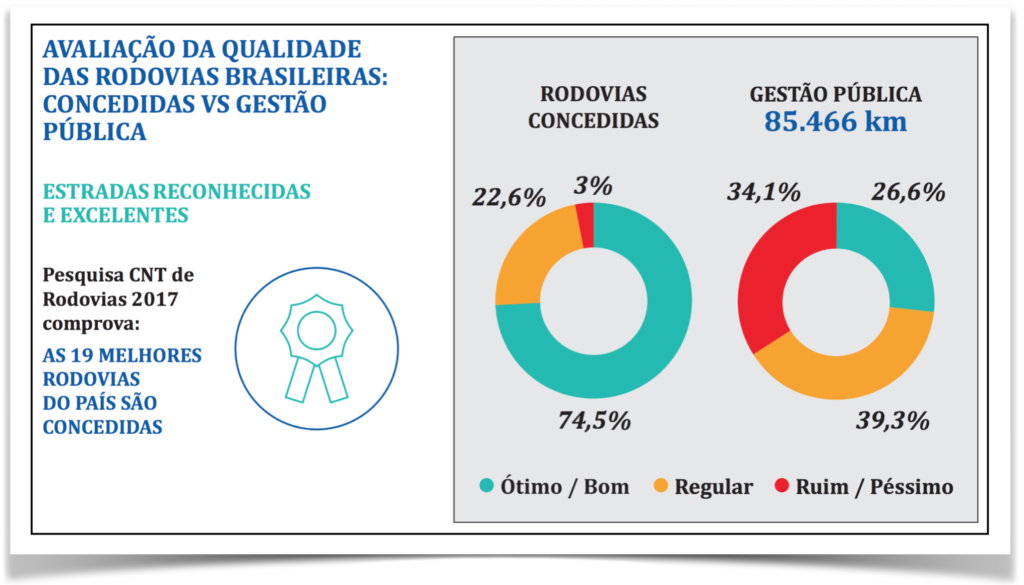

## 9.2 mapa rodoviário

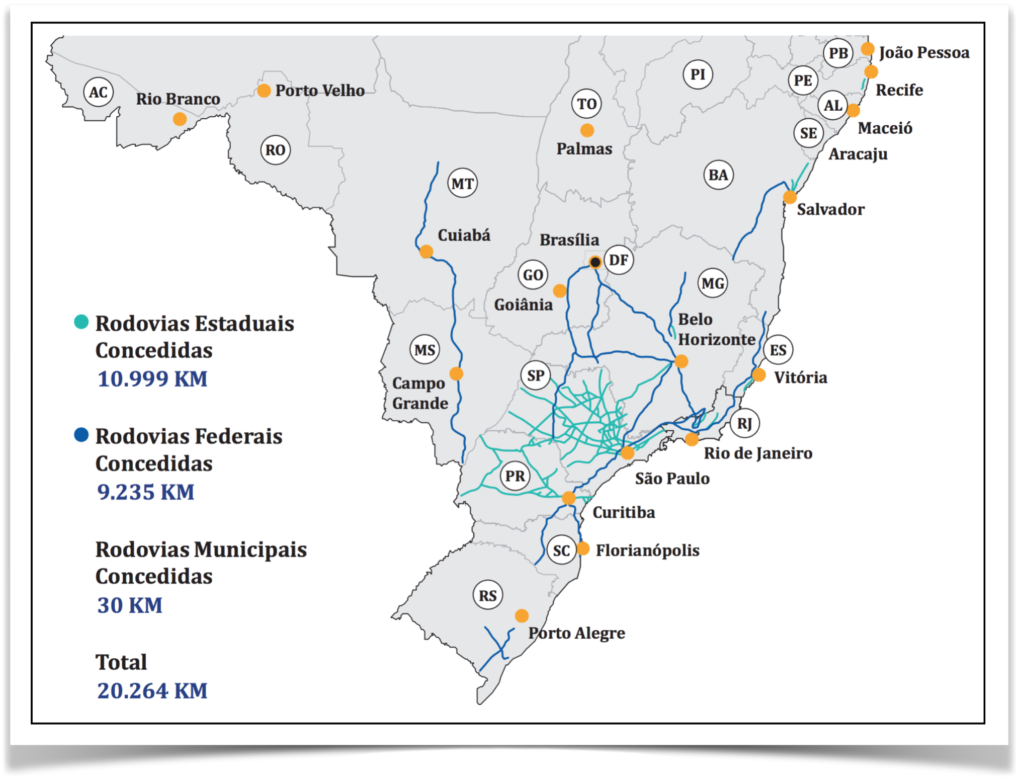

# 10 O custo de uma Estatal

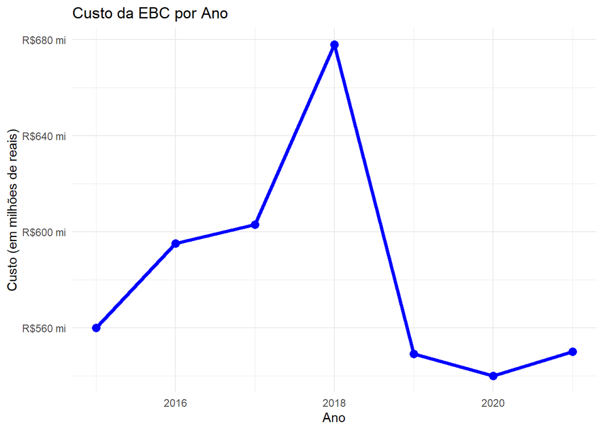

> total de R$ 550 milhões orçados para a EBC, quase R$ 400 milhões (exatos R$ 378,4 milhões) são só em salários.

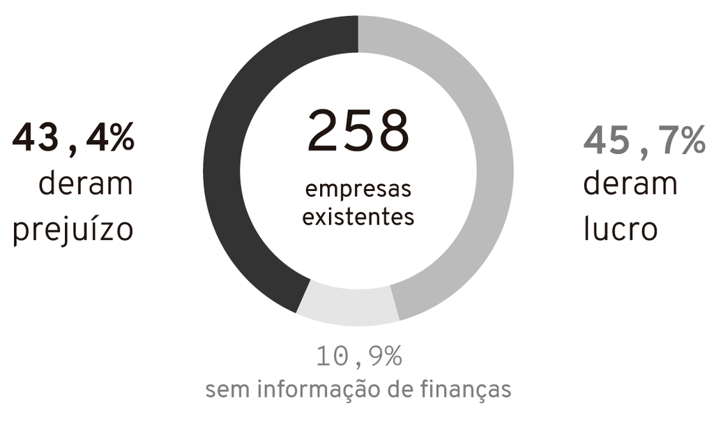

links:

https://www1.folha.uol.com.br/mercado/2019/07/privatizada-br-distribuidora-e-80-mais-valiosa.shtml

https://www.infomoney.com.br/guias/o-que-e-privatizacao/

https://ineep.org.br/privatizacao-da-liquigas-defesa-da-concorrencia-ou-promocao-do-oligopolio-privado/

https://www.correiobraziliense.com.br/opiniao/2021/11/4961328-30-anos-de-privatizacao-da-usiminas-o-presente-e-o-futuro-da-companhia.html

https://www.poder360.com.br/conteudo-patrocinado/abcr-entrega-documento-a-candidatos-para-aprimorar-concessoes-de-rodovias/

https://www.uol.com.br/splash/noticias/ooops/2021/03/11/dos-r-550-mi-que-a-ebc-custa-r-378-mi-sao-so-em-salarios.htm?cmpid=copiaecola

https://infograficos.gazetadopovo.com.br/politica/financas-das-empresas-estatais-estaduais/